# 2022 MLB Pitcher Data Analysis

Kieran O’Sullivan

2025-08-01

## Library

```r
library(ggplot2)
library(caret)
library(randomForest)
library(xgboost)
library(e1071)
library(corrplot)
options(scipen = 999)
```

## Data Loading and Augmentations

```r
original_data <- read.csv("2022 MLB Player Stats - Pitching.csv",sep=";")
```

### Fix Names

```r
original_data$Name <- iconv(original_data$Name, from = "", to = "UTF-8", sub = "")
original_data$Name <- gsub("\\*", "", original_data$Name)
```

### Track Original Dimensions

```r
dim(original_data)
```

```
## [1] 1081   35
```

### Add Division Attribute

```r
require(dplyr)
original_data$Div <- ifelse(original_data$Tm %in% c("LAD", "SDP", "SFG", "ARI", "COL",
                                         "SEA", "LAA", "OAK", "HOU", "TEX"), "West",
          ifelse(original_data$Tm %in% c("MIN", "CLE", "CHW", "DET", "KCR", "MIL",
                              "STL", "CHC", "CIN", "PIT"), "Central",
          ifelse(original_data$Tm %in% c("NYY", "BOS", "TBR", "TOR", "BAL", "ATL",
                              "PHI", "NYM", "WSN", "MIA"), "East",
                 "MULT")))
original_data <- original_data %>% relocate(Div, .after = Lg)
```

### Rename Columns

```r
original_data <- original_data[, -1]
colnames(original_data) <- c("Name", "Age", "Team", "League", "Div", "Wins", "Losses", "WLPercent", "ERA","G", "GS", "GF", "CG", "SHO", "SV", "IP", "H", "R", "ER", "HR", "BB", "IBB", "SO", "HBP", "BK", "WP", "BF", "ERA+", "FIP", "WHIP", "H9", "HR9", "BB9", "SO9", "SOperBB")
```

### Remove Duplicate Player Entries

```r
df_grouped <- original_data %>%
  group_by(Name) %>%
  filter(if (any(League == "MLB")) League == "MLB" else row_number() == 1) %>%
  ungroup()
```

### Add “Throws”

```r
throws_data <- read.csv("throws.csv")
df_grouped$Throws <- throws_data[[1]]
df_grouped <- df_grouped %>% relocate(Throws, .after = Div)
```

### Set Row Identifier to Player Names

```r
df_grouped <- as.data.frame(df_grouped)
#player_names <- df_grouped$Name
rownames(df_grouped) <- df_grouped$Name
df_grouped$Name <- NULL
```

### Sort By ERA+ (Eventual Target Variable)

```r
df_grouped <- df_grouped[order(df_grouped$'ERA+', decreasing = TRUE),]

df_grouped <- df_grouped %>% relocate('ERA+', .after = Throws)
```

### Drop ER and ERA

```r
# First, track this metric for context purposes
percent_earned <- (sum(df_grouped$ER) / sum(df_grouped$R)) * 100
cat("Percent of Runs that become Earned Runs:", percent_earned, "%")
```

```
## Percent of Runs that become Earned Runs: 91.23558 %
```

```r
df_grouped$ER <- NULL
df_grouped$ERA <- NULL
```

### Drop Rows where ERA+ is 0 (not meaningful)

```r
sum(df_grouped$`ERA+` == 0)
```

```
## [1] 53
```

```r
df_grouped <- df_grouped %>% filter(`ERA+` > 0)
```

### Final Data

```r
df <- df_grouped
player_names <- rownames(df)
dim(df)
```

```
## [1] 815  33
```

```r
head(df)
```

```
##                Age Team League  Div Throws ERA+ Wins Losses WLPercent  G GS GF
## TylerKinley     31  COL     NL West      R  625    1      1       0.5 25  0  3
## RyanWeber       31  NYY     AL East      R  473    0      0       0.0  5  0  4
## HunterBrown     23  HOU     AL West      R  438    2      0       1.0  7  2  0
## YencyAlmonte    28  LAD     NL West      R  402    0      0       0.0 33  0  3
## LuisOrtiz       26  SFG     NL West      R  400    0      0       0.0  6  0  4
## ScottAlexander  32  SFG     NL West      L  391    0      0       0.0 17  4  3
##                CG SHO SV   IP  H R HR BB IBB SO HBP BK WP  BF  FIP  WHIP  H9
## TylerKinley     0   0  0 24.0 21 5  0  6   0 27   1  0  2 100 1.74 1.125 7.9
## RyanWeber       0   0  1 10.2  6 1  1  1   0  3   0  0  0  37 4.05 0.656 5.1
## HunterBrown     0   0  0 20.1 15 2  0  7   0 22   0  0  0  80 1.98 1.082 6.6
## YencyAlmonte    0   0  1 35.1 18 4  2 10   1 33   4  0  0 135 3.17 0.792 4.6
## LuisOrtiz       0   0  0  8.2  5 1  0  3   0  6   0  0  0  33 2.77 0.923 5.2
## ScottAlexander  0   0  2 17.1 12 2  1  1   0 10   0  0  0  63 2.88 0.750 6.2
##                HR9 BB9  SO9 SOperBB
## TylerKinley    0.0 2.3 10.1    4.50
## RyanWeber      0.8 0.8  2.5    3.00
## HunterBrown    0.0 3.1  9.7    3.14
## YencyAlmonte   0.5 2.5  8.4    3.30
## LuisOrtiz      0.0 3.1  6.2    2.00
## ScottAlexander 0.5 0.5  5.2   10.00
```

```r
tail(df)
```

```
##                  Age Team League     Div Throws ERA+ Wins Losses WLPercent G GS
## BrendonLittle     25  CHC     NL Central      L   16    0      1         0 1  0
## BrianMoran        33  LAA     AL    West      L   16    0      0         0 1  0
## AlbertPujols      42  STL     NL Central      R   15    0      0         0 1  0
## MaxSchrock        27  CIN     NL Central      R   13    0      0         0 1  0
## AndreltonSimmons  32  CHC     NL Central      R   13    0      0         0 1  0
## JoshVanMeter      27  PIT     NL Central      R   12    0      0         0 3  0
##                  GF CG SHO SV  IP  H  R HR BB IBB SO HBP BK WP BF   FIP   WHIP
## BrendonLittle     0  0   0  0 0.2  2  3  1  1   0  0   1  0  0  6 31.61  4.500
## BrianMoran        0  0   0  0 0.1  3  2  1  1   1  0   0  0  0  5 51.11 12.000
## AlbertPujols      1  0   0  0 1.0  3  4  2  1   0  0   0  0  0  7 32.11  4.000
## MaxSchrock        1  0   0  0 1.0  7  5  2  0   0  0   0  0  0 10 29.11  7.000
## AndreltonSimmons  1  0   0  0 1.0  5  5  0  1   0  0   0  0  0  9  6.11  6.000
## JoshVanMeter      3  0   0  0 3.0 15 13  5  2   0  0   0  0  0 27 26.78  5.667
##                  H9  HR9  BB9 SO9 SOperBB
## BrendonLittle    27 13.5 13.5   0       0
## BrianMoran       81 27.0 27.0   0       0
## AlbertPujols     27 18.0  9.0   0       0
## MaxSchrock       63 18.0  0.0   0       0
## AndreltonSimmons 45  0.0  9.0   0       0
## JoshVanMeter     45 15.0  6.0   0       0
```

```r
df_scaled <- df %>% mutate(across(where(is.numeric), scale))
df_scaled_numeric <- df_scaled[sapply(df_scaled, is.numeric)]
df_numeric <- df[sapply(df, is.numeric)]

#write.csv(df, "pitching_data_final_format.csv")
```

## Exploratory Data Analysis

### Any missing or n/a values?

```r
colSums(is.na(df))
```

```
##       Age      Team    League       Div    Throws      ERA+      Wins    Losses
##         0         0         0         0         0         0         0         0
## WLPercent         G        GS        GF        CG       SHO        SV        IP
##         0         0         0         0         0         0         0         0
##         H         R        HR        BB       IBB        SO       HBP        BK
##         0         0         0         0         0         0         0         0
##        WP        BF       FIP      WHIP        H9       HR9       BB9       SO9
##         0         0         0         0         0         0         0         0
##   SOperBB
##         0
```

### ERA+ Outlier Discussion

The greatest career ERA+ of all time is 205, for Mariano Rivera. Given this, assign 205 as the cutoff for outlier values on the high end. Potential reasons for a player exceeding this in a one season sample size:

- Elite-level reliever.
- Extremely small sample size.
- Abnormally “lucky” season.

```r
outlier_cutoff <- 205
```

```r
sum(df$`ERA+` > outlier_cutoff)
```

```
## [1] 36
```

```r
df[df$`ERA+`>outlier_cutoff, c("ERA+", "IP")]
```

```
##                 ERA+    IP
## TylerKinley      625  24.0
## RyanWeber        473  10.2
## HunterBrown      438  20.1
## YencyAlmonte     402  35.1
## LuisOrtiz        400   8.2
## ScottAlexander   391  17.1
## FernandoCruz     372  14.2
## JosCisnero       362  25.0
## EvanPhillips     357  63.0
## PeteFairbanks    334  24.0
## RyneStanek       333  54.2
## RyanHelsley      316  64.2
## EdwinDaz         297  62.0
## TylerGlasnow     290   6.2
## MatthewBoyd      285  13.1
## MattGage         283  13.0
## EmmanuelClase    281  72.2
## RyneNelson       278  18.1
## CionelPrez       278  57.2
## DannyCoulombe    277  12.1
## DreyJameson      276  24.1
## MarcosDipln      262   5.2
## DanielBard       260  60.1
## AnthonyBass      259  70.1
## AngelZerpa       255  11.0
## AlexisDaz        244  63.2
## BlakeTreinen     242   5.0
## MarkAppel        239  10.1
## JasonAdam        238  63.1
## AndreJackson     226   9.2
## CalebFerguson    225  34.2
## ErikSwanson      224  53.2
## JustinVerlander  218 175.0
## LukeBard         217  15.0
## JhoanDuran       212  67.2
## DevinWilliams    209  60.2
```

### ERA+ Histogram

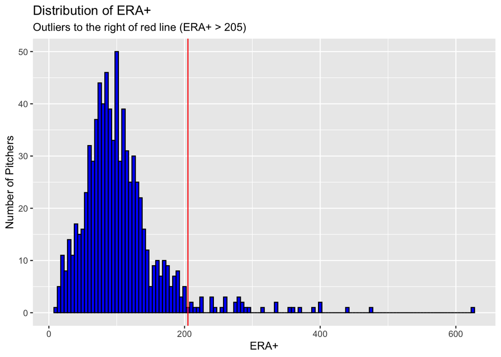

```r
ggplot(df) +
  aes(x = `ERA+`) +
  geom_histogram(binwidth = 5, fill = "blue", color = "black") +
  geom_vline(xintercept = outlier_cutoff, color = "red") +
  ggtitle("Distribution of ERA+","Outliers to the right of red line (ERA+ > 205)") +
  labs(x = "ERA+",y = "Number of Pitchers")
```

### ERA+ by Principal Components

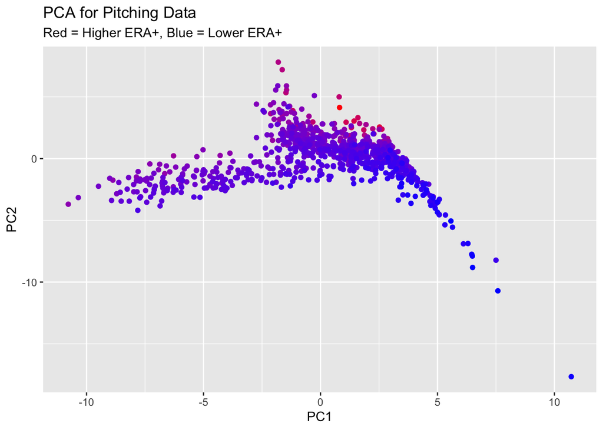

```r
set.seed(42)
prcomp_p <- data.frame(
  prcomp(x = df_scaled_numeric)$x[,1:2],
  Name = player_names,
  Rank = df$`ERA+`
)
ggplot(prcomp_p) +
  aes(x = PC1,y = PC2,color = Rank,label = Name) +
  geom_point() +
  scale_color_gradient(low = "blue", high = "red",) +
  ggtitle("PCA for Pitching Data","Red = Higher ERA+, Blue = Lower ERA+") +
  theme(legend.position = "none")
```

### Cluster based on presumed position

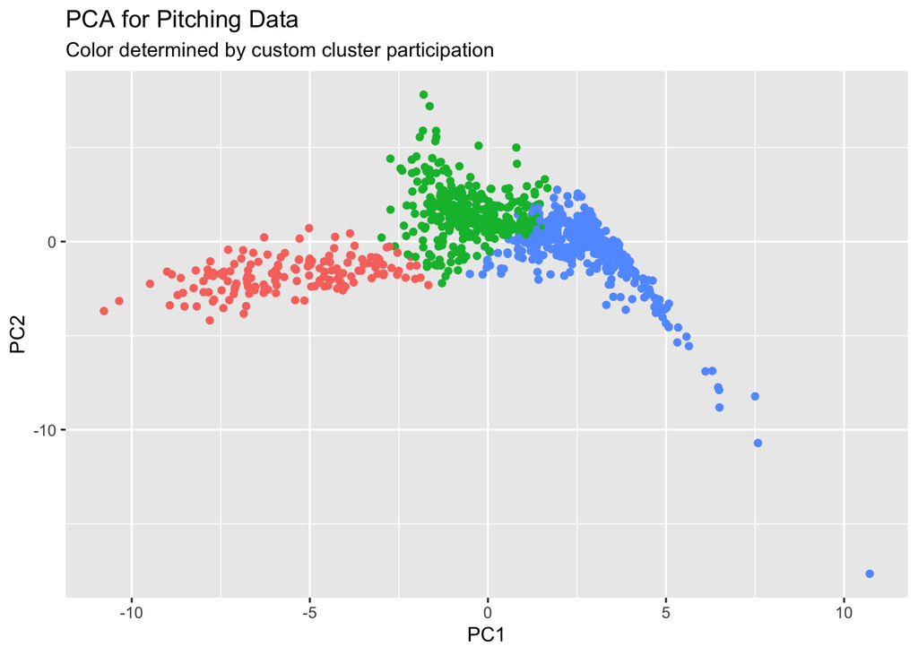

```r
set.seed(42)

zeroes <- rep(0, length.out = length(colnames(df_scaled_numeric)))
starting_pitchers <- zeroes
starting_pitchers[which(colnames(df_scaled_numeric)=="GS")] <- 3
closing_pitchers <- zeroes
closing_pitchers[which(colnames(df_scaled_numeric)=="G")] <- 3
other_pitchers <- zeroes

initial_centers <- matrix(
  data = c(starting_pitchers, closing_pitchers, other_pitchers),
  nrow = 3,
  byrow = TRUE
)
rownames(initial_centers) <- c("starters","closers/relievers","other")
kmeans_customCenters <- kmeans(x = df_scaled_numeric, centers = initial_centers)
#kmeans_customCenters$centers

prcomp_custom <- data.frame(
  prcomp(
  x = df_scaled_numeric)$x[,1:2],
  Name = rownames(df_scaled_numeric),
  Rank = df_scaled_numeric$`ERA+`,
  Cluster = as.character(kmeans_customCenters$cluster)
)
ggplot(prcomp_custom) +
  aes(x = PC1,y = PC2,color = Cluster) +
  geom_point() +
  ggtitle("PCA for Pitching Data","Color determined by custom cluster participation") +
  theme(legend.position = "none")
```

Red = C1 / Starters, Green = C2 / Relievers+Closers, Blue = C3 / No Distinction

### Variable Correlation

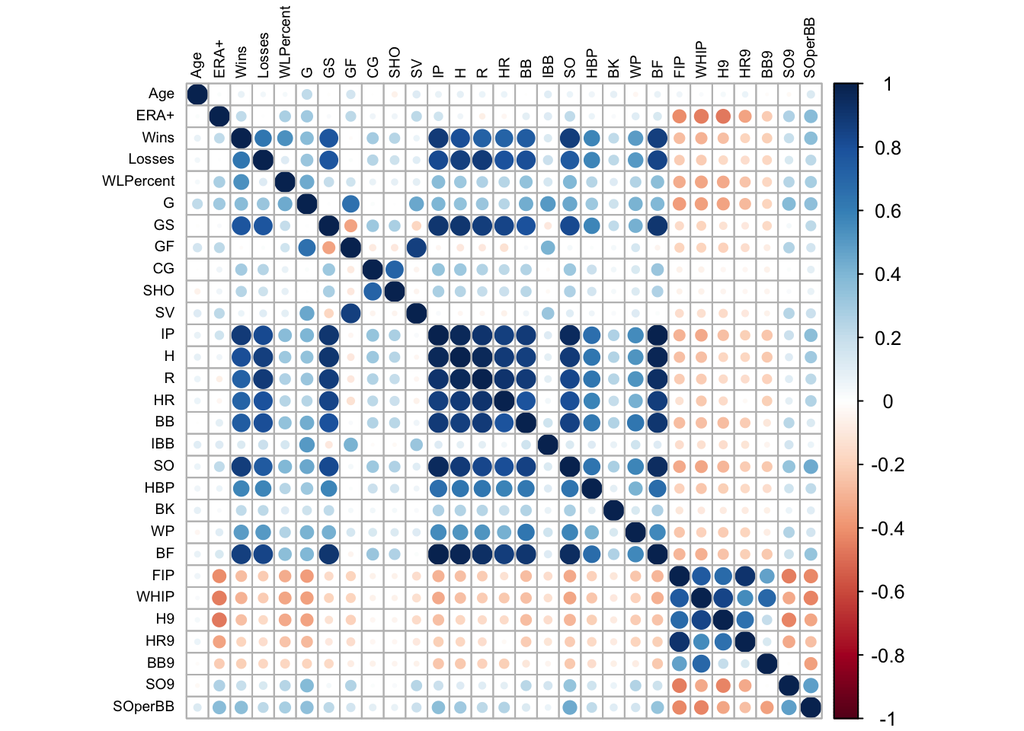

```r
corr_matrix <- cor(df_numeric)
corrplot(corr_matrix,
     tl.col = "black",
     tl.cex = 0.6)
```

```r
corr_matrix
```

```
##                     Age         ERA+        Wins       Losses   WLPercent
## Age        1.0000000000  0.017145443  0.07393145  0.042457187  0.03012211
## ERA+       0.0171454431  1.000000000  0.21286925  0.004870726  0.27475606
## Wins       0.0739314471  0.212869247  1.00000000  0.633984438  0.53047571
## Losses     0.0424571874  0.004870726  0.63398444  1.000000000  0.11869554
## WLPercent  0.0301221117  0.274756058  0.53047571  0.118695543  1.00000000
## G          0.2189850913  0.302830764  0.37615298  0.328869052  0.44100937
## GS        -0.0069650889  0.022909518  0.77307962  0.779558653  0.20329883
## GF         0.1579103679  0.224064929 -0.01163834  0.013694724  0.16158739
## CG        -0.0003792312  0.052351325  0.29070888  0.246621143  0.07259890
## SHO       -0.0575147855  0.053211526  0.24159880  0.174747571  0.08322839
## SV         0.1111954157  0.220021921  0.06317843  0.100753107  0.09430297
## IP         0.0724380551  0.163727604  0.88286102  0.823595079  0.37752506
## H          0.0804875015  0.050797273  0.80773296  0.862146384  0.31415314
## R          0.0670580307 -0.061997523  0.72845373  0.886538176  0.26813518
## HR         0.0667374246 -0.037918011  0.71024765  0.797749083  0.24832440
## BB        -0.0017281063  0.097026965  0.74249692  0.808155022  0.34891217
## IBB        0.1027233662  0.119011302  0.12150385  0.189676915  0.14848573
## SO         0.0650330972  0.217641469  0.87592054  0.758932350  0.39561029
## HBP        0.0570496327  0.061069686  0.57229565  0.576655838  0.24744088
## BK         0.0832800205  0.022653079  0.21877280  0.221144962  0.11475412
## WP        -0.0358824931  0.107212205  0.49266667  0.509531338  0.25841945
## BF         0.0707298784  0.136037588  0.86747642  0.842628695  0.36649181
## FIP        0.0549825550 -0.410036398 -0.26588964 -0.213281277 -0.31105158
## WHIP       0.0219856713 -0.455156254 -0.29696878 -0.218103332 -0.33596618
## H9         0.0391113294 -0.461408068 -0.25096420 -0.165815253 -0.32472800
## HR9        0.0636711357 -0.340982507 -0.18225823 -0.144945680 -0.24017826
## BB9       -0.0127817166 -0.213356526 -0.20663539 -0.176409387 -0.17911151
## SO9       -0.0254976117  0.267055557  0.19601114  0.130450513  0.24344491
## SOperBB    0.1209085411  0.378550579  0.36309397  0.226637756  0.28710680
##                       G           GS          GF            CG           SHO
## Age        0.2189850913 -0.006965089  0.15791037 -0.0003792312 -0.0575147855
## ERA+       0.3028307637  0.022909518  0.22406493  0.0523513253  0.0532115258
## Wins       0.3761529813  0.773079615 -0.01163834  0.2907088796  0.2415987965
## Losses     0.3288690517  0.779558653  0.01369472  0.2466211433  0.1747475709
## WLPercent  0.4410093683  0.203298826  0.16158739  0.0725989004  0.0832283928
## G          1.0000000000  0.007211324  0.65297986  0.0188545828  0.0006298806
## GS         0.0072113240  1.000000000 -0.34106059  0.3127004036  0.2769327124
## GF         0.6529798624 -0.341060589  1.00000000 -0.0882397900 -0.0928834791
## CG         0.0188545828  0.312700404 -0.08823979  1.0000000000  0.7110758926
```

[output cut: 125 more lines]

```
## HR        -0.02607445 -0.20576219  0.09408414  0.25747777
## BB        -0.21567158 -0.10285377  0.23087412  0.12580274
## IBB       -0.11655153 -0.04930000  0.15134371  0.06496435
## SO        -0.21103685 -0.22267726  0.33411781  0.44196077
## HBP       -0.16655873 -0.14487689  0.16872786  0.21567226
## BK        -0.08119045 -0.06372134  0.06830014  0.10809088
## WP        -0.18763397 -0.07630760  0.25403952  0.15810349
## BF        -0.20097147 -0.22921408  0.17695524  0.33967733
## FIP        0.91326546  0.47016086 -0.45237603 -0.42488792
## WHIP       0.55221675  0.69461418 -0.32497368 -0.43856770
## H9         0.65311045  0.20310105 -0.43777676 -0.33285792
## HR9        1.00000000  0.13250738 -0.32495409 -0.25069832
## BB9        0.13250738  1.00000000 -0.00619333 -0.35582206
## SO9       -0.32495409 -0.00619333  1.00000000  0.48871629
## SOperBB   -0.25069832 -0.35582206  0.48871629  1.00000000
```

### ERA+ by Division

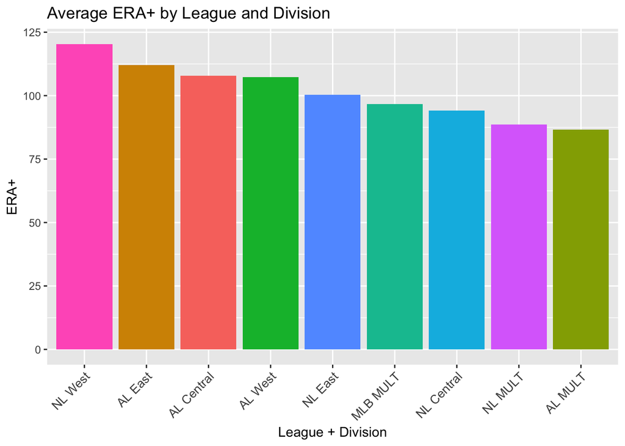

```r
df_summary <- df %>%
  mutate(League_Division = paste(League, Div)) %>%
  group_by(League_Division) %>%
  summarise(Avg_ERAplus = mean(`ERA+`), .groups = "drop")

ggplot(df_summary, aes(x = reorder(League_Division, -Avg_ERAplus), y = Avg_ERAplus, fill = League_Division)) +
  geom_col(show.legend = FALSE) +
  ggtitle("Average ERA+ by League and Division") +
  labs(x = "League + Division", y = "ERA+") +
  theme(
    axis.text.x = element_text(angle = 45, hjust = 1, size = 10)
  )
```

### ERA+ By Team

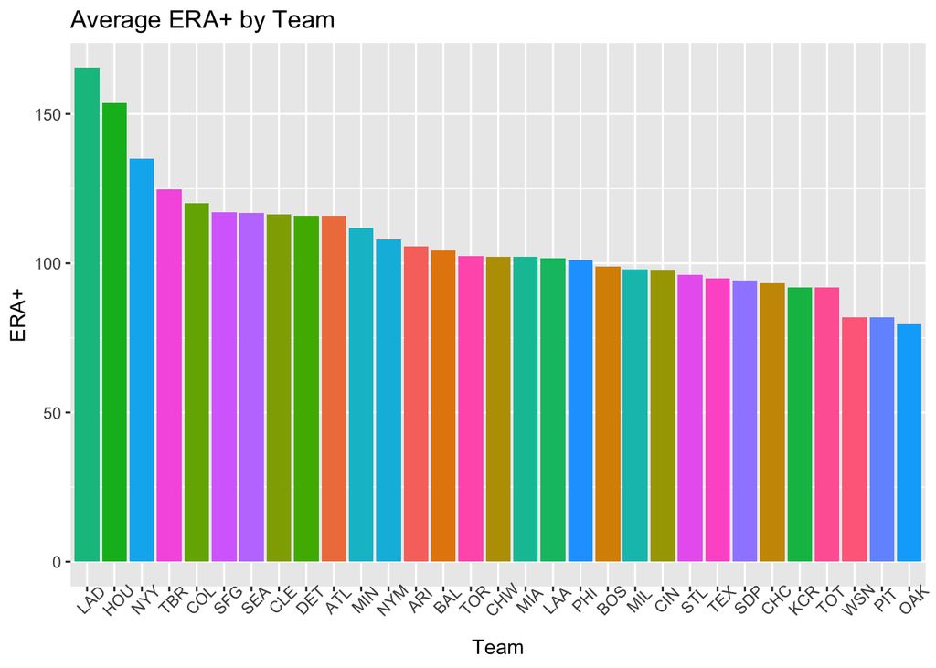

```r
df %>%
  group_by(Team) %>%
  summarise(Avg_ERAplus = mean(`ERA+`)) %>%
  ggplot(aes(x = reorder(Team, -Avg_ERAplus), y = Avg_ERAplus, fill = Team)) +
  ggtitle("Average ERA+ by Team") +
  geom_col(show.legend = FALSE) +
  labs(x = "Team", y = "ERA+") +
  theme(axis.text.x = element_text(angle = 45)
  )
```

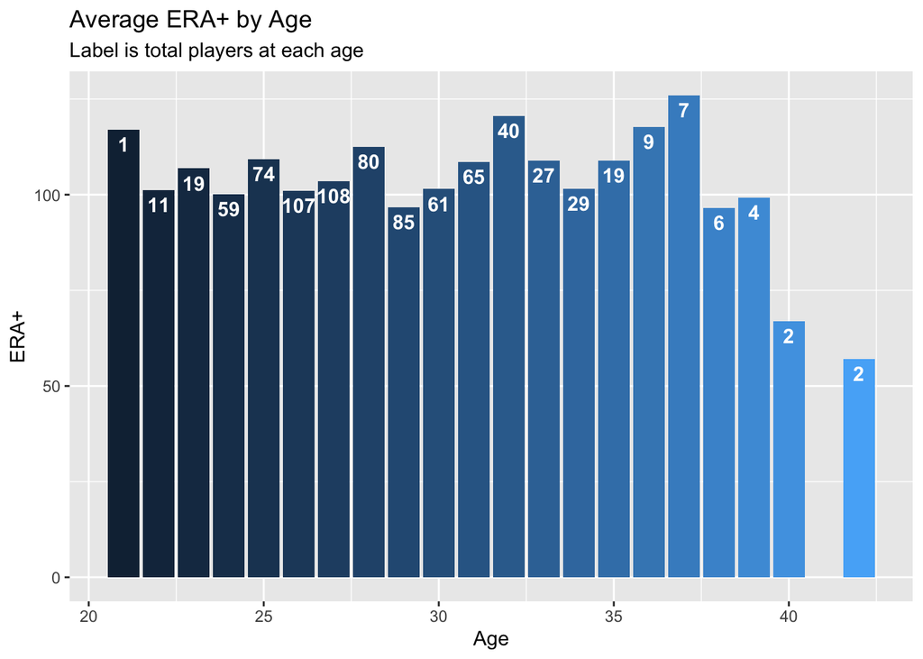

```r
df %>%
  group_by(Age) %>%
  summarise(Avg_ERAplus = mean(`ERA+`), Count = n()) %>%
  ggplot(aes(x = Age, y = Avg_ERAplus, fill = Age)) +
  ggtitle("Average ERA+ by Age", "Label is total players at each age") +
  geom_col(show.legend = FALSE) +
    geom_text(
    aes(label = Count),
    vjust = 1.5,
    color = "white",
    fontface = "bold"
  ) +
  labs(x = "Age", y = "ERA+")
```

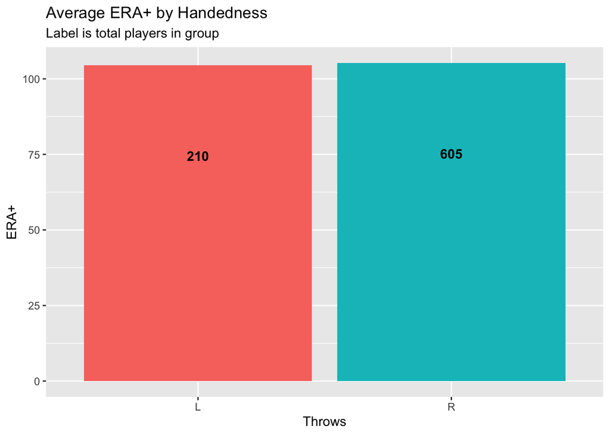

```r
df %>%
  group_by(Throws) %>%
  summarise(Avg_ERAplus = mean(`ERA+`), Count = n()) %>%
  ggplot(aes(x = Throws, y = Avg_ERAplus, fill = Throws)) +
  geom_col(show.legend = FALSE) +
  ggtitle("Average ERA+ by Handedness", "Label is total players in group") +
  geom_text(aes(label = Count),
    vjust = 10,
    color = "black",
    fontface = "bold"
  ) +
  labs(x = "Throws", y = "ERA+")
```

## ERA+ Prediction

### Variable Selection

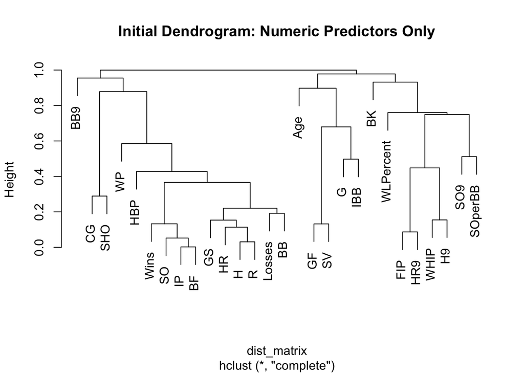

```r
predictors <- df_numeric
predictors$`ERA+` <- NULL
dist_matrix <- as.dist(1-abs(cor(predictors)))
dend <- hclust(dist_matrix)
plot(dend, main = "Initial Dendrogram: Numeric Predictors Only")
```

```r
set.seed(42)
# Scale everything but ERA+. Its format is scaled and the interpretation is not something I want to lose.
df_var_sel <- df %>% mutate(across(where(is.numeric)& !all_of("ERA+"), scale))

baseline_lm <- lm(`ERA+` ~ ., data = df_var_sel)
stepwise_model <- step(baseline_lm, direction = "both",
                       k = log(nrow(df_var_sel)), trace = FALSE)
summary(stepwise_model)
```

```
##
## Call:
## lm(formula = `ERA+` ~ Wins + Losses + WLPercent + R + BB + SO +
##     BF + H9 + SOperBB + BB9, data = df_var_sel)
##
## Residuals:
##     Min      1Q  Median      3Q     Max
## -102.05  -21.42   -9.02    7.76  464.35
##
## Coefficients:
##             Estimate Std. Error t value             Pr(>|t|)
## (Intercept)  105.094      1.521  69.103 < 0.0000000000000002 ***
## Wins         -12.894      4.028  -3.201             0.001422 **
## Losses        10.666      3.558   2.998             0.002806 **
## WLPercent      5.777      2.079   2.778             0.005590 **
## R           -105.576      6.430 -16.421 < 0.0000000000000002 ***
## BB            17.190      4.662   3.688             0.000242 ***
## SO           -22.223      6.366  -3.491             0.000508 ***
## BF           103.735     10.377   9.997 < 0.0000000000000002 ***
## H9           -14.453      1.782  -8.111  0.00000000000000187 ***
## SOperBB       13.475      2.253   5.982  0.00000000331559703 ***
## BB9           -4.681      1.682  -2.783             0.005507 **
## ---
## Signif. codes:  0 '***' 0.001 '**' 0.01 '*' 0.05 '.' 0.1 ' ' 1
##
## Residual standard error: 43.42 on 804 degrees of freedom
## Multiple R-squared:  0.4849, Adjusted R-squared:  0.4785
## F-statistic: 75.68 on 10 and 804 DF,  p-value: < 0.00000000000000022
```

Suggested Variables:

- Wins (W)
- Losses (L)
- Win/Loss % (WLPercent) - *removed*
- Runs (R)
- Walks (BB)
- Strikeouts (SO)
- Batters Faced (BF)
- Hits / 9 Innings Pitched (H9) - *removed*
- Walks / 9 Innings Pitched (BB9) - *removed*
- Strikeouts / Walk (SOperBB) - *removed*

Remove WLPercent, SOperBB, H9, BB9

Added FIP, WHIP

### Final Predictors

- Wins
- Losses
- R
- WHIP
- SO
- BF
- BB
- FIP

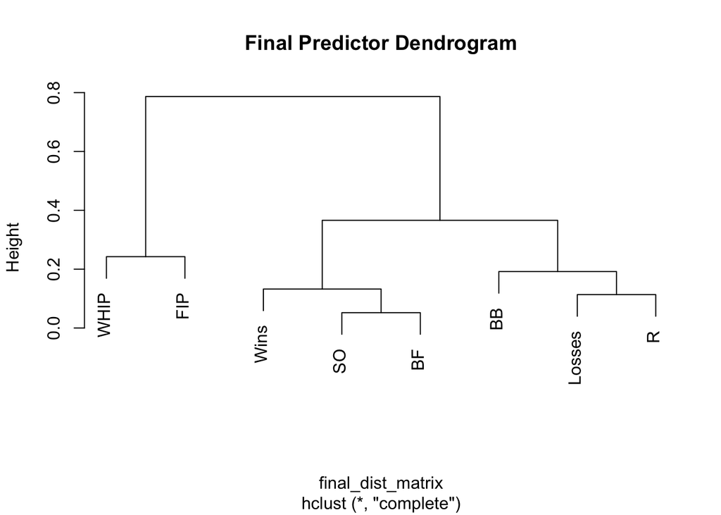

```r
final_preds_list <- c("ERA+", "Wins", "Losses", "R", "WHIP", "SO", "BF", "BB", "FIP")
df_final <- df_var_sel[final_preds_list]
final_preds <- df_final
final_preds$`ERA+` <- NULL
final_dist_matrix <- as.dist(1-abs(cor(final_preds)))
final_dend <- hclust(final_dist_matrix)
plot(final_dend, main = "Final Predictor Dendrogram")
```

## Models

### Split Data

```r
set.seed(42)
train_indices <- sample(1:nrow(df_final), size = 0.8 * nrow(df_final))
train_data <- df_final[train_indices, ]
test_data <- df_final[-train_indices, ]

actuals <- test_data$`ERA+`
```

### Linear Regression

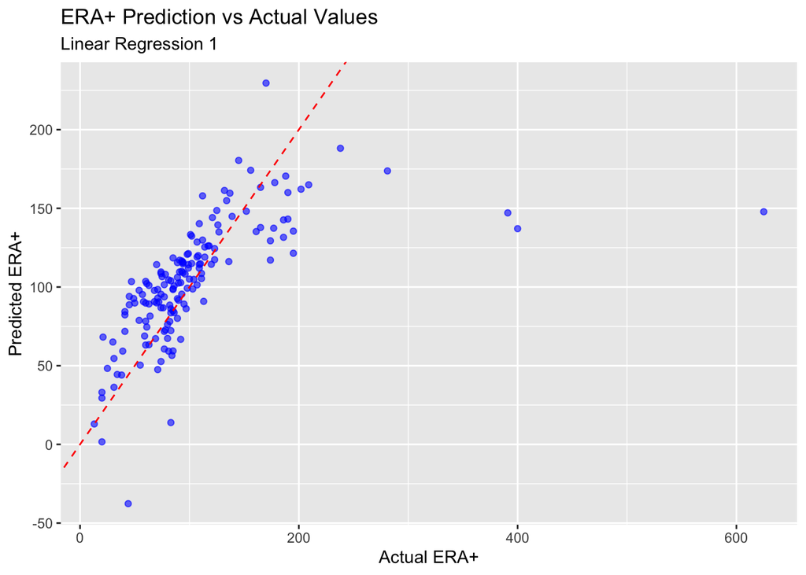

```r
set.seed(42)
lin_reg_1 <- lm(`ERA+` ~ ., data = train_data)
#summary(lin_reg_1)

preds_lm <- predict(lin_reg_1, test_data)

rmse_lm <- sqrt(mean((preds_lm - actuals)^2))
mae_lm <- mean(abs(preds_lm - actuals))
r_squared_lm <- cor(preds_lm, actuals)^2

#cat("RMSE:", rmse_lm, "\nMAE:", mae_lm, "\nR-squared:", r_squared_lm)
results_lm <- data.frame(
  Actual_ERA_Plus = actuals,
  Predicted_ERA_Plus = round(preds_lm,2)
)
#results_lm
ggplot(results_lm, aes(x = Actual_ERA_Plus, y = Predicted_ERA_Plus)) +
  geom_point(alpha = 0.6, color = "blue") +
  geom_abline(slope = 1, intercept = 0, color = "red", linetype = "dashed") +
  ggtitle("ERA+ Prediction vs Actual Values", "Linear Regression 1") +
  labs(
    x = "Actual ERA+",
    y = "Predicted ERA+"
  )
```

Linear regression displays very poor metrics so far. Lets see if using cross validation could help.

### Linear Regression (With 5-Fold Cross Validation)

```r
set.seed(42)
train_control <- trainControl(method = "cv", number = 5)
lin_reg_2 <- train(`ERA+` ~ ., data = df_final, method = "lm", trControl = train_control)
lin_reg_2
```

```
## Linear Regression
##
## 815 samples
##   8 predictor
##
## No pre-processing
## Resampling: Cross-Validated (5 fold)
## Summary of sample sizes: 653, 652, 653, 651, 651
## Resampling results:
##
##   RMSE     Rsquared   MAE
##   45.1271  0.4562429  26.7407
##
## Tuning parameter 'intercept' was held constant at a value of TRUE
```

The results are only slightly better.

## Random Forest Model

### RF1

```r
set.seed(42)
rf_model_1 <- randomForest(`ERA+` ~ ., data=train_data, ntree = 600, importance = TRUE, mtry = 5)
rf_model_1
```

```
##
## Call:
##  randomForest(formula = `ERA+` ~ ., data = train_data, ntree = 600,      importance = TRUE, mtry = 5)
##                Type of random forest: regression
##                      Number of trees: 600
## No. of variables tried at each split: 5
##
##           Mean of squared residuals: 1090.817
##                     % Var explained: 67.06
```

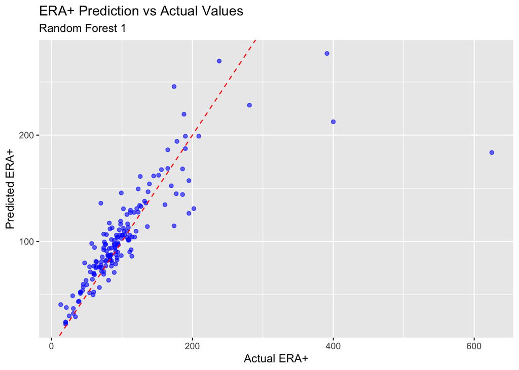

```r
preds_rf1 <- predict(rf_model_1, test_data)

#Metrics
rmse_rf1 <- sqrt(mean((preds_rf1 - actuals)^2))
mae_rf1 <- mean(abs(preds_rf1 - actuals))
r_squared_rf1 <- cor(preds_rf1, actuals)^2

results_rf1 <- data.frame(
  Actual_ERA_Plus = actuals,
  Predicted_ERA_Plus = round(preds_rf1,2)
)
#results_rf1

ggplot(results_rf1, aes(x = Actual_ERA_Plus, y = Predicted_ERA_Plus)) +
  geom_point(alpha = 0.6, color = "blue") +
  geom_abline(slope = 1, intercept = 0, color = "red", linetype = "dashed") +
  ggtitle("ERA+ Prediction vs Actual Values", "Random Forest 1") +
  labs(
    x = "Actual ERA+",
    y = "Predicted ERA+"
  )
```

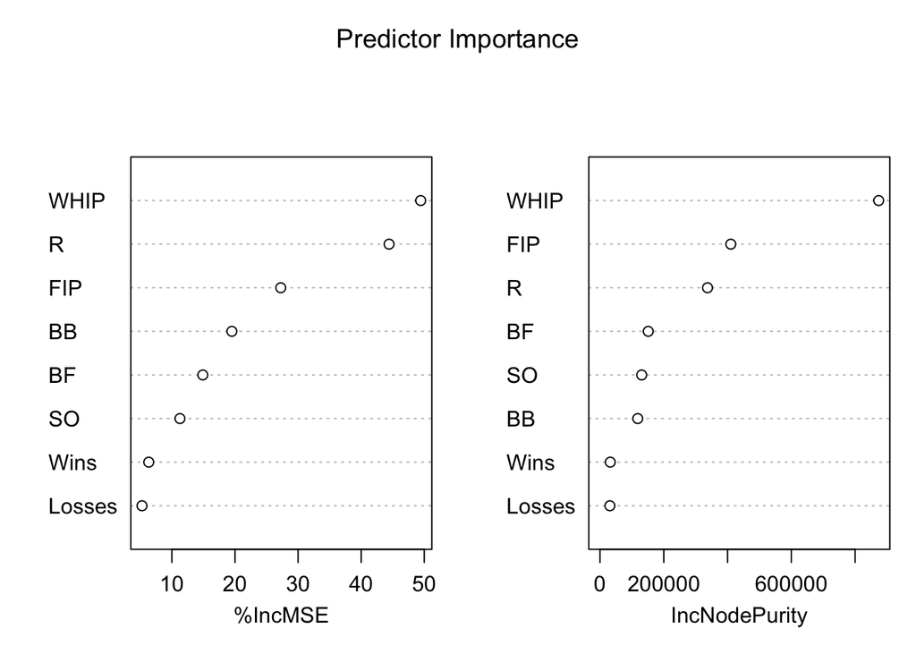

```r
varImpPlot(rf_model_1, main="Predictor Importance")
```

### RF2

```r
set.seed(42)
rf_model_2 <- randomForest::randomForest(`ERA+` ~ ., data=train_data, ntree = 1000, importance = TRUE,mtry = 7)
rf_model_2
```

```
##
## Call:
##  randomForest(formula = `ERA+` ~ ., data = train_data, ntree = 1000,      importance = TRUE, mtry = 7)
##                Type of random forest: regression
##                      Number of trees: 1000
## No. of variables tried at each split: 7
##
##           Mean of squared residuals: 1105.803
##                     % Var explained: 66.61
```

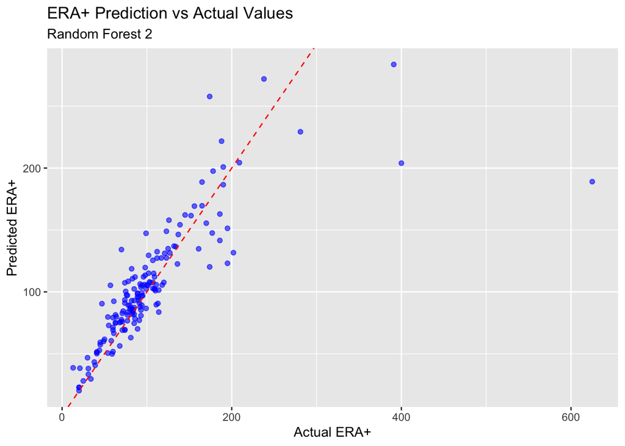

```r
preds_rf2 <- predict(rf_model_2, test_data)

#Metrics
rmse_rf2 <- sqrt(mean((preds_rf2 - actuals)^2))
mae_rf2 <- mean(abs(preds_rf2 - actuals))
r_squared_rf2 <- cor(preds_rf2, actuals)^2

results_rf2 <- data.frame(
  Actual_ERA_Plus = actuals,
  Predicted_ERA_Plus = round(preds_rf2,2)
)
#results_rf2

ggplot(results_rf2, aes(x = Actual_ERA_Plus, y = Predicted_ERA_Plus)) +
  geom_point(alpha = 0.6, color = "blue") +
  geom_abline(slope = 1, intercept = 0, color = "red", linetype = "dashed") +
  ggtitle("ERA+ Prediction vs Actual Values", "Random Forest 2") +
  labs(
    x = "Actual ERA+",
    y = "Predicted ERA+"
  )
```

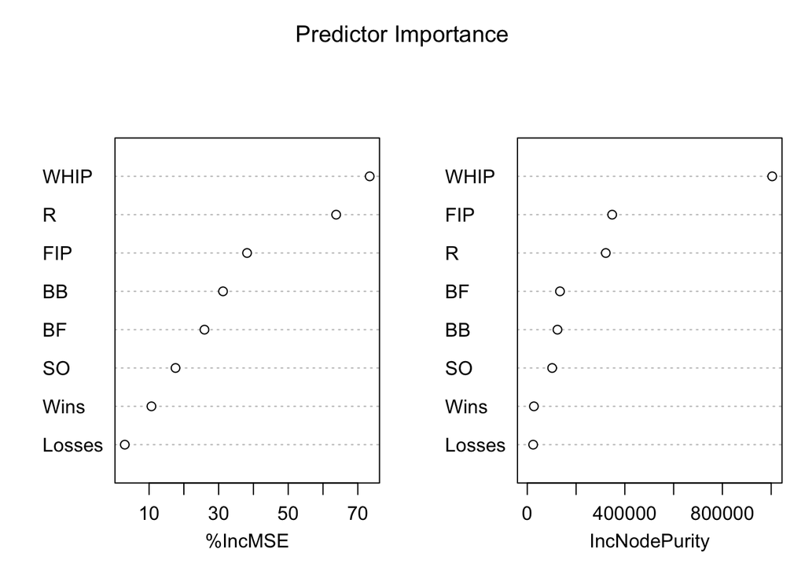

```r
varImpPlot(rf_model_2, main="Predictor Importance")
```

### RF3

```r
set.seed(42)
rf_model_3 <- randomForest(`ERA+` ~ ., data=train_data, ntree = 1000, importance = TRUE,mtry = ncol(train_data)-1)
rf_model_3
```

```
##
## Call:
##  randomForest(formula = `ERA+` ~ ., data = train_data, ntree = 1000,      importance = TRUE, mtry = ncol(train_data) - 1)
##                Type of random forest: regression
##                      Number of trees: 1000
## No. of variables tried at each split: 8
##
##           Mean of squared residuals: 1109.452
##                     % Var explained: 66.5
```

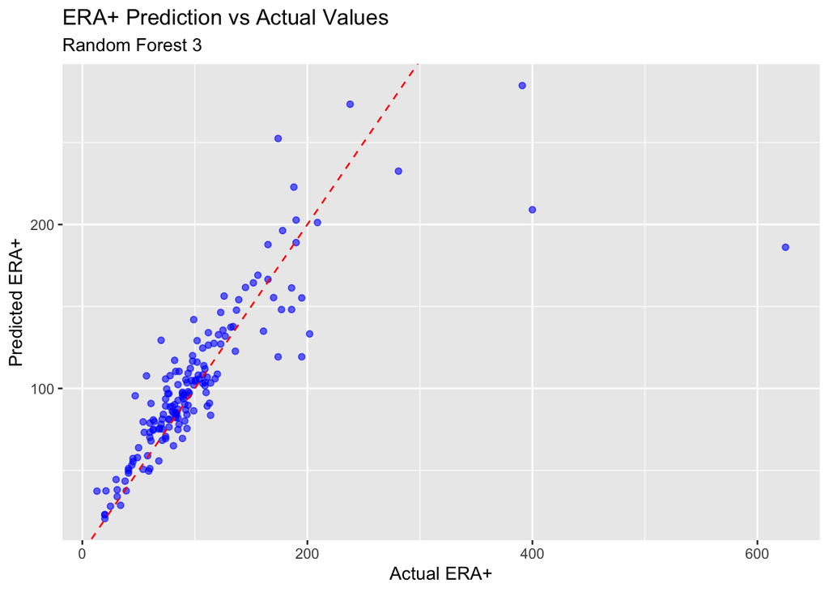

```r
preds_rf3 <- predict(rf_model_3, test_data)

rmse_rf3 <- sqrt(mean((preds_rf3 - actuals)^2))
mae_rf3 <- mean(abs(preds_rf3 - actuals))
r_squared_rf3 <- cor(preds_rf3, actuals)^2


results_rf3 <- data.frame(
  Actual_ERA_Plus = actuals,
  Predicted_ERA_Plus = round(preds_rf3,2)
)
#results_rf3

ggplot(results_rf3, aes(x = Actual_ERA_Plus, y = Predicted_ERA_Plus)) +
  geom_point(alpha = 0.6, color = "blue") +
  geom_abline(slope = 1, intercept = 0, color = "red", linetype = "dashed") +
  ggtitle("ERA+ Prediction vs Actual Values", "Random Forest 3") +
  labs(x = "Actual ERA+", y = "Predicted ERA+")
```

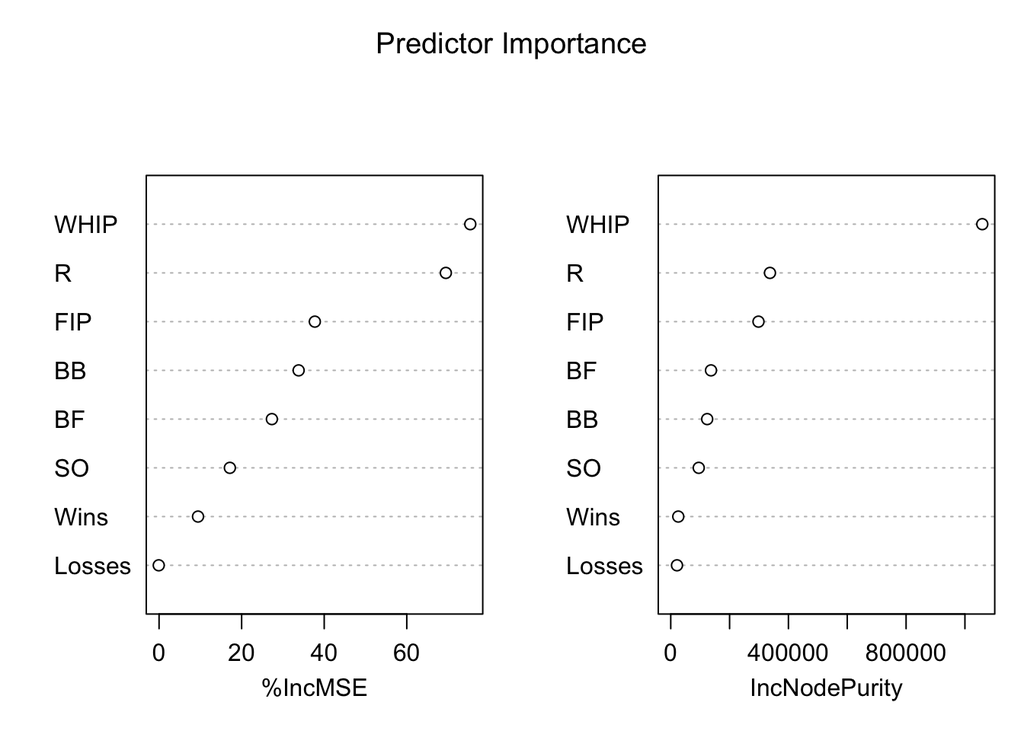

```r
varImpPlot(rf_model_3, main="Predictor Importance")
```

### Support Vector Regression

```r
set.seed(42)
svr_model <- svm(`ERA+` ~ .,
                 data = train_data, kernel = "radial", cost = 100)
summary(svr_model)
```

```
##
## Call:
## svm(formula = `ERA+` ~ ., data = train_data, kernel = "radial", cost = 100)
##
##
## Parameters:
##    SVM-Type:  eps-regression
##  SVM-Kernel:  radial
##        cost:  100
##       gamma:  0.125
##     epsilon:  0.1
##
##
## Number of Support Vectors:  432
```

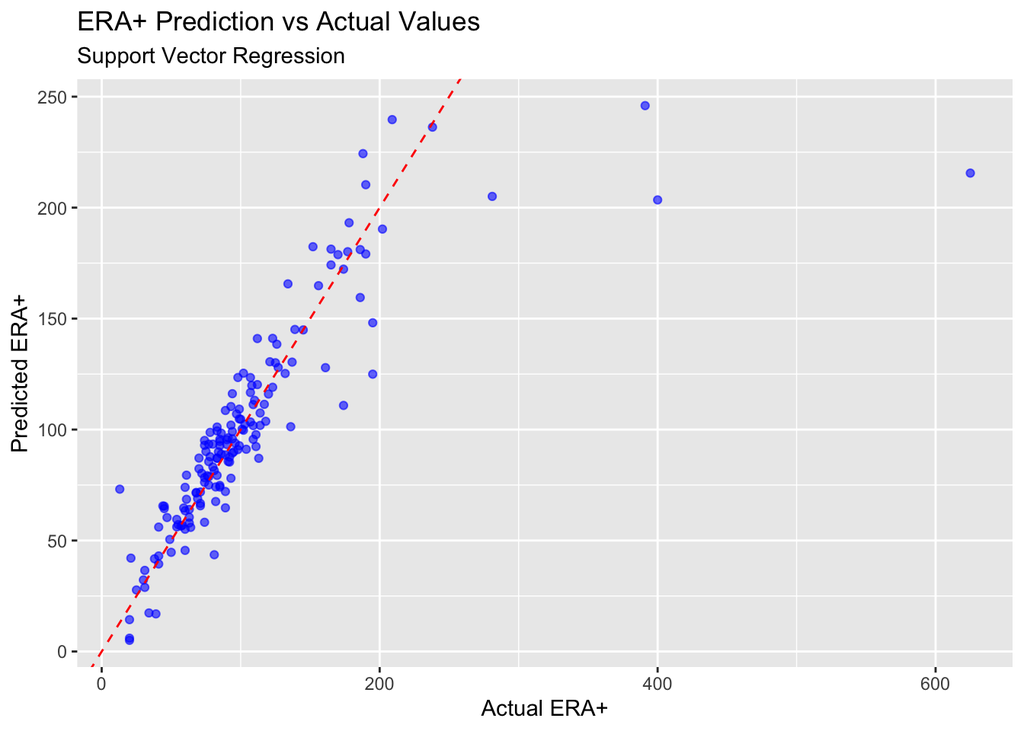

```r
preds_svr <- predict(svr_model, test_data)

rmse_svr <- sqrt(mean((preds_svr - actuals)^2))
mae_svr <- mean(abs(preds_svr - actuals))
r_squared_svr <- cor(preds_svr, actuals)^2

results_svr <- data.frame(
  Actual_ERA_Plus = actuals,
  Predicted_ERA_Plus = round(preds_svr,2)
)

svr_plot <- ggplot(results_svr, aes(x = Actual_ERA_Plus, y = Predicted_ERA_Plus)) +
  geom_point(alpha = 0.6, color = "blue") +
  geom_abline(slope = 1, intercept = 0, color = "red", linetype = "dashed") +
  ggtitle("ERA+ Prediction vs Actual Values", "Support Vector Regression") +
  labs(
    x = "Actual ERA+",
    y = "Predicted ERA+"
  )
svr_plot
```

### XGBoost

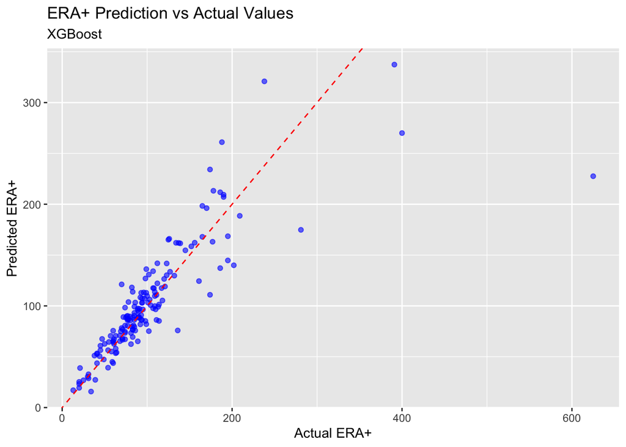

```r
set.seed(42)

X_train <- as.matrix(train_data %>% select(-`ERA+`))
y_train <- as.matrix(train_data$`ERA+`)
X_test <- as.matrix(test_data %>% select(-`ERA+`))
y_test <- as.matrix(test_data$`ERA+`)

xgb_model <- xgboost(data = X_train, label = y_train,
  nrounds = 100,
  eval_metric = "rmse",
  verbose = 0
)

y_pred <- predict(xgb_model, X_test)

mae_xgb <- mean(abs(y_pred - y_test))
rmse_xgb <- sqrt(mean((y_pred - y_test)^2))
r2_xgb <- 1 - sum((y_test - y_pred)^2) / sum((y_test - mean(y_test))^2)


importance <- xgb.importance(model = xgb_model)

results_xgb <- data.frame(
  Actual_ERA_Plus = actuals,
  Predicted_ERA_Plus = round(y_pred,2)
)

xgb_plot <- ggplot(results_xgb, aes(x = Actual_ERA_Plus, y = Predicted_ERA_Plus)) +
  geom_point(alpha = 0.6, color = "blue") +
  geom_abline(slope = 1, intercept = 0, color = "red", linetype = "dashed") +
  ggtitle("ERA+ Prediction vs Actual Values", "XGBoost") +
  labs(x = "Actual ERA+",y = "Predicted ERA+")
xgb_plot
```

### Model Metrics

```r
model_metrics <- data.frame(
  Model = c("Linear Regression 1", "Linear Regression 2", "Random Forest 1","Random Forest 2","Random Forest 3", "SVR", "XGB"),
  ModelNotes = c("Baseline MLR", "Used 5-Fold CV", "ntree = 600, mtry = 5","ntree = 1000, mtry = 7","Bagging","radial kernel","nrounds = 100"),
  RMSE = c(rmse_lm, lin_reg_2$results$RMSE, rmse_rf1, rmse_rf2, rmse_rf3, rmse_svr, rmse_xgb),
  MAE = c(mae_lm, lin_reg_2$results$MAE, mae_rf1, mae_rf2, mae_rf3, mae_svr, mae_xgb),
  "R^2" = c(r_squared_lm, lin_reg_2$results$Rsquared, r_squared_rf1, r_squared_rf2, r_squared_rf3, r_squared_svr, r2_xgb)
)
model_metrics
```

```
##                 Model             ModelNotes     RMSE      MAE       R.2
## 1 Linear Regression 1           Baseline MLR 54.57706 27.92153 0.3860267
## 2 Linear Regression 2         Used 5-Fold CV 45.12710 26.74070 0.4562429
## 3     Random Forest 1  ntree = 600, mtry = 5 43.44129 18.85381 0.6249807
## 4     Random Forest 2 ntree = 1000, mtry = 7 43.50486 19.02332 0.6202718
## 5     Random Forest 3                Bagging 43.33645 18.73468 0.6231234
## 6                 SVR          radial kernel 41.08773 16.30716 0.6717771
## 7                 XGB          nrounds = 100 39.79975 18.44049 0.6697623
```

Models 6 and 7 have similar performance, and their own arguments for best model. Since 7 (XGBoost) has minimal hyper-parameter tuning, lower RMSE (overall accuracy in prediction), comparable R2 (0.002 less than M6), and ability to view variable importance, it is selected as the top-performing model for predicting ERA+.

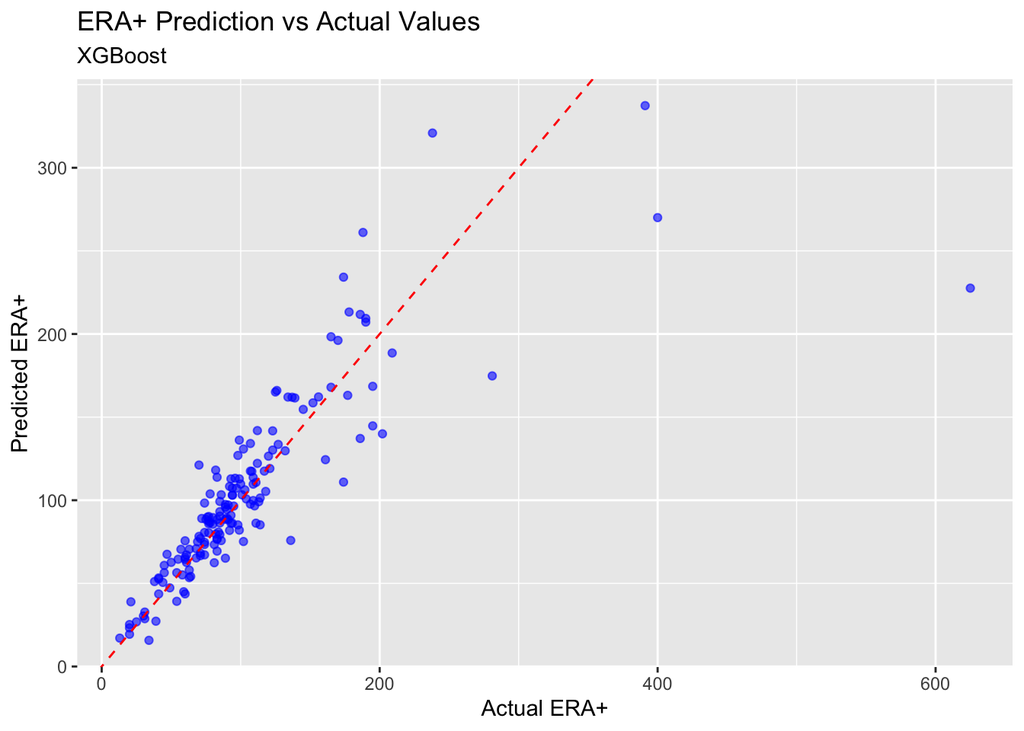

```r
xgb_plot
```

```r
results_xgb
```

```
##     Actual_ERA_Plus Predicted_ERA_Plus
## 1               625             227.58
## 2               400             270.02
## 3               391             337.37
## 4               281             174.80
## 5               238             320.89
## 6               209             188.58
## 7               202             139.96
## 8               195             168.53
## 9               195             144.72
## 10              190             209.36
## 11              190             207.16
## 12              188             261.07
## 13              186             211.78
## 14              186             137.15
```

[output cut: 149 more lines]

### Success with outliers vs normal data

```r
outlier_predictions <- subset(results_xgb, Actual_ERA_Plus > 205)
normal_predictions <- subset(results_xgb, Actual_ERA_Plus <= 205)

mean(abs(outlier_predictions$Actual_ERA_Plus - outlier_predictions$Predicted_ERA_Plus))
```

```
## [1] 131.7567
```

```r
mean(abs(normal_predictions$Actual_ERA_Plus - normal_predictions$Predicted_ERA_Plus))
```

```
## [1] 14.10955
```

### Most Important Statistics to Look at

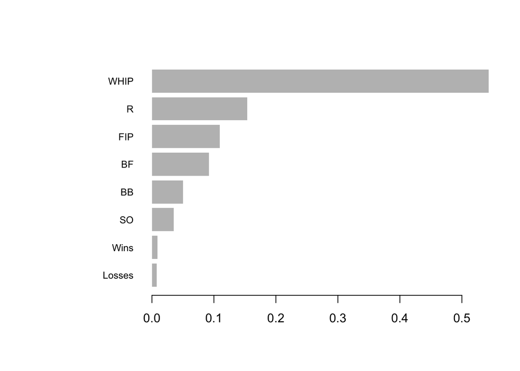

```r
xgb.plot.importance(importance)
```

## Conclusion

Key insights from entire project

- Pitchers with better (higher) ERA+ values profile more as relievers or closers, and teams may consider moving starters with such stats to higher leverage positions.
- A league average pitching staff or better should be a priority for teams attempting to compete.
- Handedness (L vs R) may matter in certain match ups, but is not a significant factor in ERA+ at a season-wide scale.
- Age is not a major factor in ERA+, until a player reaches an older stage of their careers, experiencing physical decline.
- The XGBoost model outperformed others, slightly edging out SVR, making it the most effective model for ERA+ prediction given the current dataset. Performs very well on normal data, struggles with outliers.
- Among all predictors, WHIP emerged as the strongest predictor of ERA+, and is a core metric team executives and coaches should refer to when evaluating pitcher performance.